# P4 - Alimentos básicos Latinoamericanos

### ▲▼▲▼▲▼▲▼▲▼▲▼▲ Prueba de normalidad ▼▲▼▲▼▲▼▲▼▲▼

¿ Nuestros vectores de datos tienen una distribución normal ? Aplicaremos diferentes maneras para determinar esta cuestión

```r
require(rriskDistributions)
# fit.cont(DFAR$`Trigo MIN USD/Kg`) # NO RECHAZADO NORMAL
```

#### **Tipo de distribución de datos**

Desarrollando el siguiente procedimiento, tenemos que poner a prueba nuestros vectores de datos, necesitamos conocer si siguen una distribución normal o una distribución con otras características. Utilizando la siguiente función, podemos visualizar el análisis de cada vector evaluado.

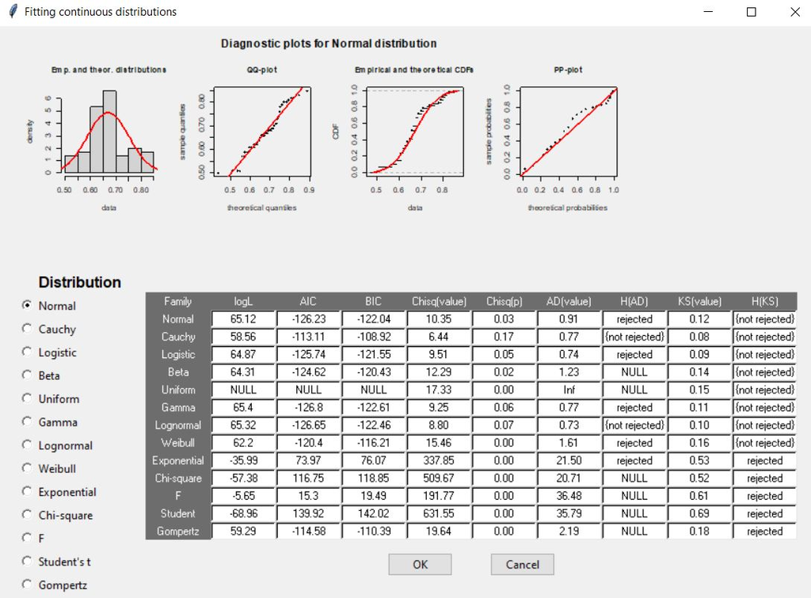

#### **Tipo de distribución de datos**

Luego de evaluar todos nuestros vectores de datos, podemos conocer los que presentan una distribución normal, esta información nos permitirá proseguir con las siguientes evaluaciones para fines del estudio.

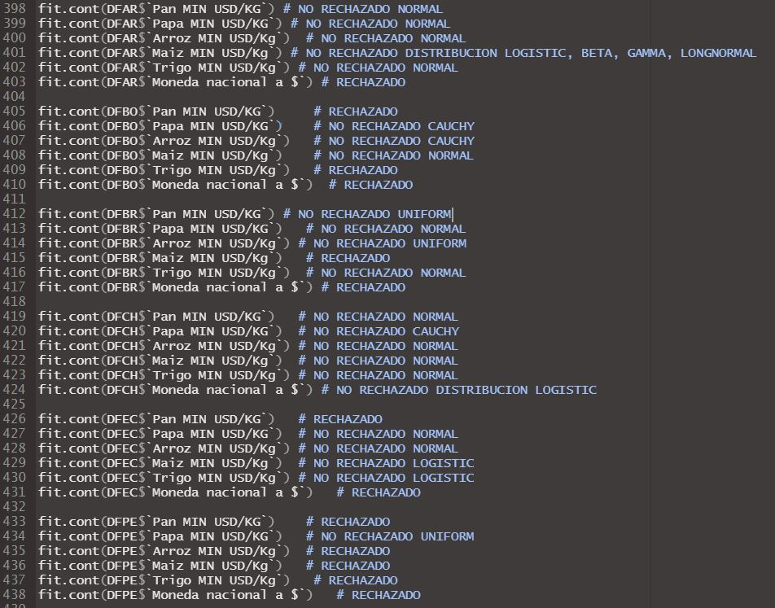

### ▲▼▲▼▲▼▲▼▲ Histograma con curva de densidad ▼▲▼▲▼▲▼▲

#### **Trigo Argentina : Gráfico inferencial**

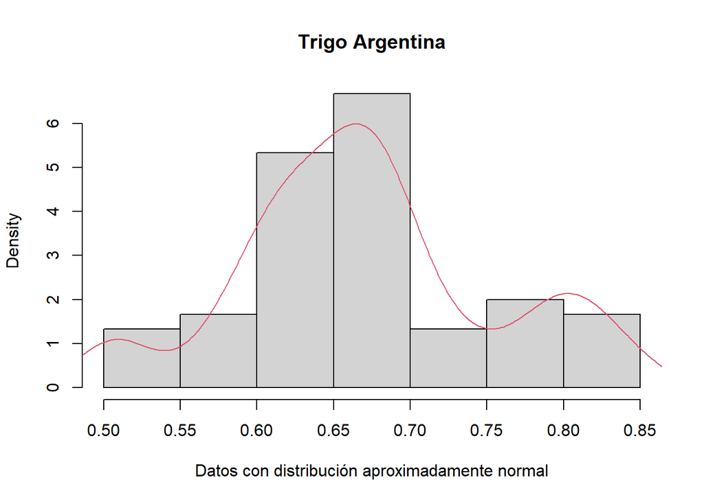

```r
hist(DFAR$`Trigo MIN USD/Kg`,probability=T, main="Trigo Argentina",xlab="Datos con distribución aproximadamente normal")
lines(density(DFAR$`Trigo MIN USD/Kg`),col=2)
```

#### **Maíz Bolivia: Gráfico inferencial**

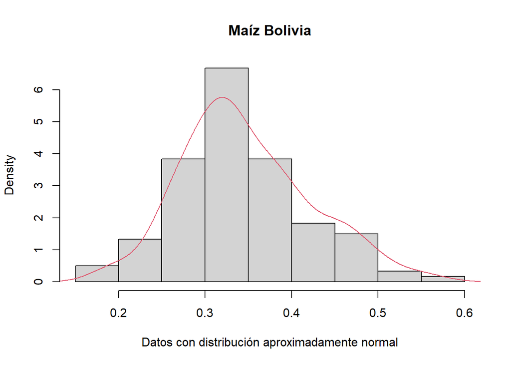

#### **Arroz Brasil: Gráfico inferencial**

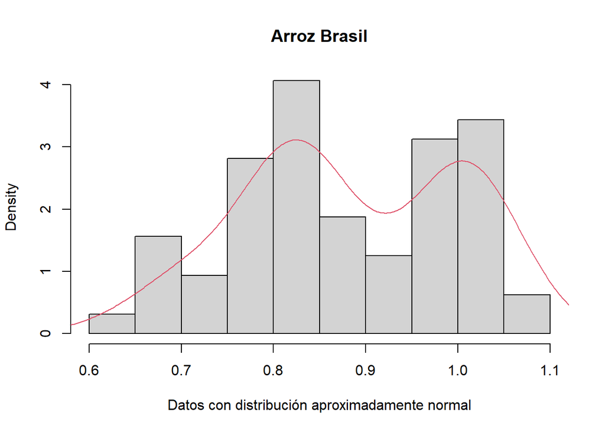

#### **Trigo Chile: Gráfico inferencial**

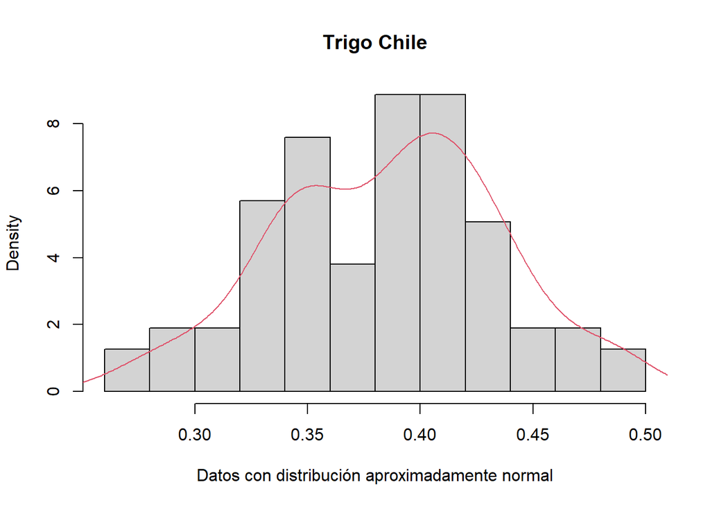

#### **Papa Ecuador: Gráfico inferencial**

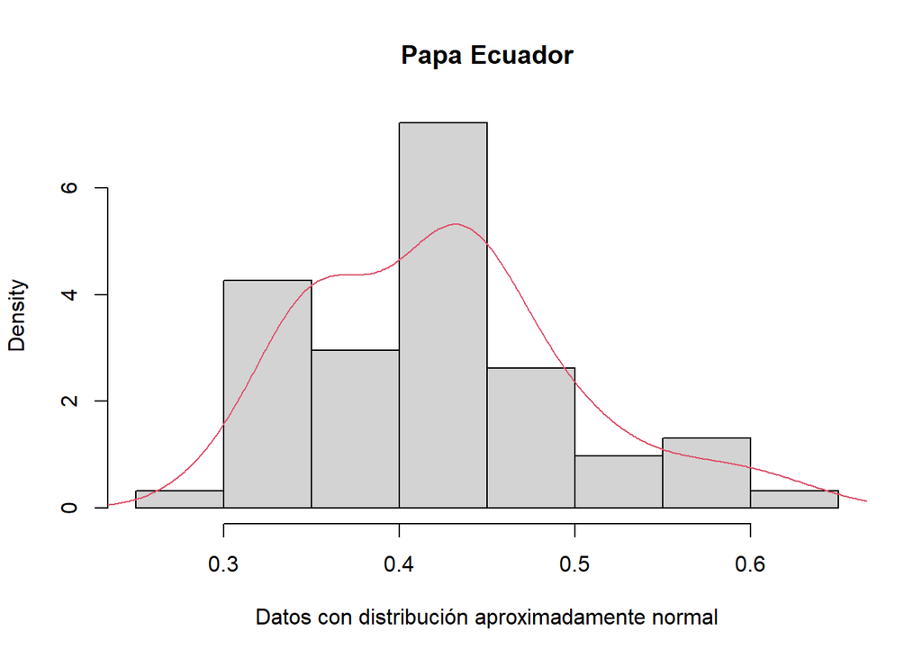

#### **Papa Perú: Gráfico inferencial**

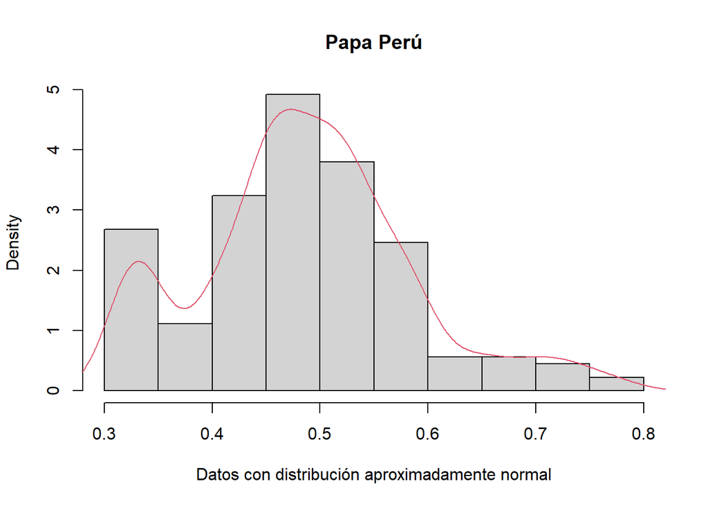

### ▲▼▲▼▲▼▲▼▲▼▲▼▲▼ Shapiro Test ▲▼▲▼▲▼▲▼▲▼▲▼▲▼▲▼

Valores críticos

```r
VC =  qnorm(0.99)
+ VC
```

```
## [1] 2.326348
```

```r
- VC
```

```
## [1] -2.326348
```

Estadístico de prueba

```r
Eprueba = (mu - xbarra) / ( S / sqrt(n) )
Eprueba
```

```
## [1] -4.986587
```

## Resultado del estadístico de prueba: Gráfico inferencial

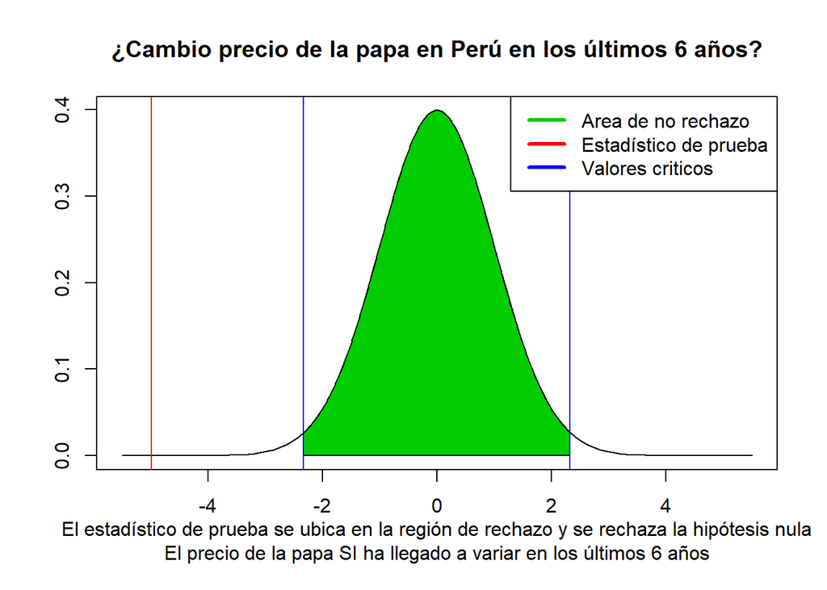

```r
cordx = c(-VC, seq(-VC,VC,0.01),VC )
cordy = c(0,dnorm(seq(-VC,VC,0.01)),0)
curve (dnorm(x,0,1),xlim = c(-5.5,5.5), main = "¿Cambio precio de la papa en Perú en los últimos 6 años?", ylab = "",xlab= "
El estadístico de prueba se ubica en la región de rechazo y se rechaza la hipótesis nula
El precio de la papa SI ha llegado a variar en los últimos 6 años" )
polygon(cordx,cordy, col = "green3")
par(new = TRUE)
abline(v=c( Eprueba,-VC,VC ), col=c("red","blue","blue") )
legend("topright",
       legend = c("Area de no rechazo","Estadístico de prueba", ("Valores criticos")),
       lty = c(1, 1), col = c("green3","red","blue"), lwd = 3)
```

#### **Hipótesis 2**

Determinar si el precio del arroz en Brasil subió los últimos 4 años 95 %

#### ► Ho: µ <= 0.8846875 (USD/Kg)

Valor crítico

```r
VC =  qnorm(1 - (alfa))
 VC
```

```
## [1] 1.644854
```

Estadístico de prueba

```r
Eprueba = (mu - xbarra) / ( S / sqrt(n) )
Eprueba
```

```
## [1] 1.044238
```

## Resultado del estadístico de prueba: Gráfico inferencial

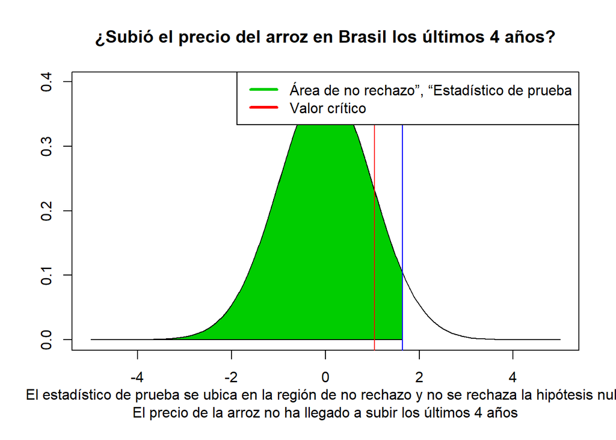

#### **Hipótesis 3**

Determinar si el precio del trigo en Chile, bajo los últimos 3 años al 97 %

#### ► Ho: µ >= 0.3862025 (USD/Kg)

Valor crítico

```r
VC =  qnorm(1 - (alfa))
- VC
```

```
## [1] -1.880794
```

Estadístico de prueba

```r
Eprueba = (mu - xbarra) / ( S / sqrt(n) )
Eprueba
```

```
## [1] 2.575299
```

## Resultado del estadístico de prueba: Gráfico inferencial

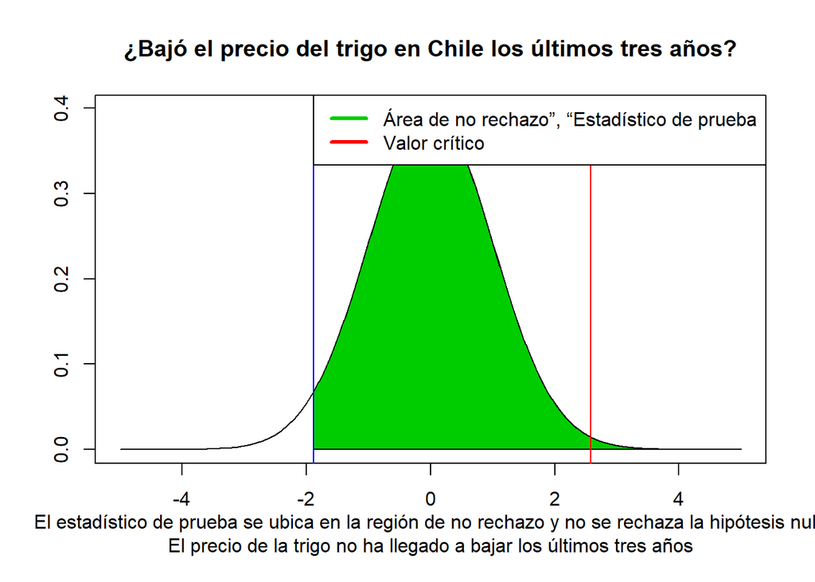

### ▲▼▲▼▲▼▲▼▲▼▲▼▲▼ REGRESION ▲▼▲▼▲▼▲▼▲▼▲▼▲▼▲▼

#### **Trigo y pan de Brasil: Gráfico inferencial**

[figure not shown]

```r
plot(DFBR$`Trigo MIN USD/Kg`~ DFBR$`Pan MIN USD/KG` ,col="blue",main=("Trigo vs Pan en Brasil"), xlab="Precio del Trigo  min (USD/Kg)
     Ecuación de regresión: Y = -0.6725814 +  4.371288 X", ylab = "Precio del Pan min (USD/Kg)")
abline(lm(DFBR$`Trigo MIN USD/Kg`~ DFBR$`Pan MIN USD/KG`), col = "red")
```

► Correlación muy buena positiva

```r
cor(DFBR$`Trigo MIN USD/Kg`, DFBR$`Pan MIN USD/KG`)
```

```
## [1] 0.9031918
```

Se observa una fuerza de relación muy cercano al valor de la unidad, esto nos indica una fuerte tendencia en las variables lo cual nos va permitir medir una tendencia lineal entre las variables.

► Coeficiente de determinación porcentual

Observamos la tendencia lineal de las variables representada por el coeficiente de determinación. El valor al ser muy cercano a la unidad, mayor será el ajuste al modelo de la variable que se intenta explicar en este ejemplo.

```r
((cor(DFBR$`Trigo MIN USD/Kg`, DFBR$`Pan MIN USD/KG`) )^2)*100
```

```
## [1] 81.57554
```

Resultado: El 81.57 % de la variación de los precios del pan es explicado por la variación del precio del trigo en Brasil.

► Ecuación de la línea de regresión

```r
lm(DFBR$`Pan MIN USD/KG`~ DFBR$`Trigo MIN USD/Kg`)
```

```
##
## Call:
## lm(formula = DFBR$`Pan MIN USD/KG` ~ DFBR$`Trigo MIN USD/Kg`)
##
## Coefficients:
##             (Intercept)  DFBR$`Trigo MIN USD/Kg`
##                 -0.6726                   4.3713
```

```r
x = DFBR$`Trigo MIN USD/Kg`
y = DFBR$`Pan MIN USD/KG`

r = cor(x,y)

b = r * sd(y) / sd(x)
b
```

```
## [1] 4.371288
```

```r
a = mean(y) - b*mean(x)
a
```

```
## [1] -0.6725814
```

Y = -0.6725814 + 4.371288 X

#### **Trigo mayorista y minorista en Brasil: Gráfico inferencial**

[figure not shown]

```r
plot(DFBR$`Trigo MAY USD/Kg` ~ DFBR$`Trigo MIN USD/Kg` ,col="blue",main=("Precio del trigo mayorista y minorista en Brasil"), xlab="Precio del trigo mayorista (USD/Kg)
     Ecuación de regresión: Y = 0.008792  + 1.559784 X", ylab = "Precio del trigo minorista (USD/Kg)")
abline(lm(DFBR$`Trigo MAY USD/Kg` ~ DFBR$`Trigo MIN USD/Kg`), col = "red")
```

► Correlación buena positiva

```r
cor(DFBR$`Trigo MAY USD/Kg` , DFBR$`Trigo MIN USD/Kg`)
```

```
## [1] 0.8369309
```

► Coeficiente de determinación porcentual

```r
((cor(DFBR$`Trigo MAY USD/Kg` , DFBR$`Trigo MIN USD/Kg`) )^2)*100
```

```
## [1] 70.04533
```

Resultado: El 70.04 % de la variación de los precios del trigo minorista es explicado por la variación del precio del trigo mayorista en Brasil

► Ecuación de la línea de regresión

```r
lm(  DFBR$`Trigo MIN USD/Kg`~  DFBR$`Trigo MAY USD/Kg`)
```

```
##
## Call:
## lm(formula = DFBR$`Trigo MIN USD/Kg` ~ DFBR$`Trigo MAY USD/Kg`)
##
## Coefficients:
##             (Intercept)  DFBR$`Trigo MAY USD/Kg`
##                0.008792                 1.559784
```

```r
x = DFBR$`Trigo MAY USD/Kg`
y = DFBR$`Trigo MIN USD/Kg`

r = cor(x,y)

b = r * sd(y) / sd(x)
b
```

```
## [1] 1.559784
```

```r
a = mean(y) - b*mean(x)
a
```

```
## [1] 0.008791631
```

Y = 0.008792 + 1.559784 X

#### **Papa mayorista y minorista en Ecuador: Gráfico inferencial**

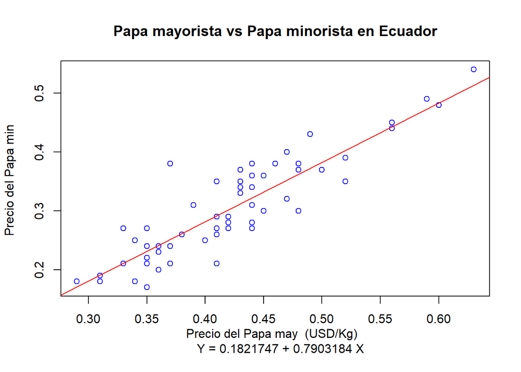

► Correlación muy buena positiva

[output not shown]

► Coeficiente de determinación porcentual

```r
((cor(DFEC$`Papa MAY USD/KG` , DFEC$`Papa MIN USD/KG`) )^2)*100
```

```
## [1] 79.69926
```

Resultado: El 79.69 % de la variación de los precios de la papa minorista, es explicado por la variación de la papa mayorista en Ecuador

► Ecuación de la línea de regresión

```r
lm(DFEC$`Papa MIN USD/KG`~ DFEC$`Papa MAY USD/KG`   )
```

```
##
## Call:
## lm(formula = DFEC$`Papa MIN USD/KG` ~ DFEC$`Papa MAY USD/KG`)
##
## Coefficients:
##            (Intercept)  DFEC$`Papa MAY USD/KG`
##                 0.1822                  0.7903
```

```r
x = DFEC$`Papa MAY USD/KG`
y = DFEC$`Papa MIN USD/KG`

r = cor(x,y)

b = r * sd(y) / sd(x)
b
```

```
## [1] 0.7903184
```

```r
a = mean(y) - b*mean(x)
a
```

```
## [1] 0.1821747
```

Y = 0.1821747 + 0.7903184 X

#### **Maíz y pan de Chile: Gráfico inferencial**

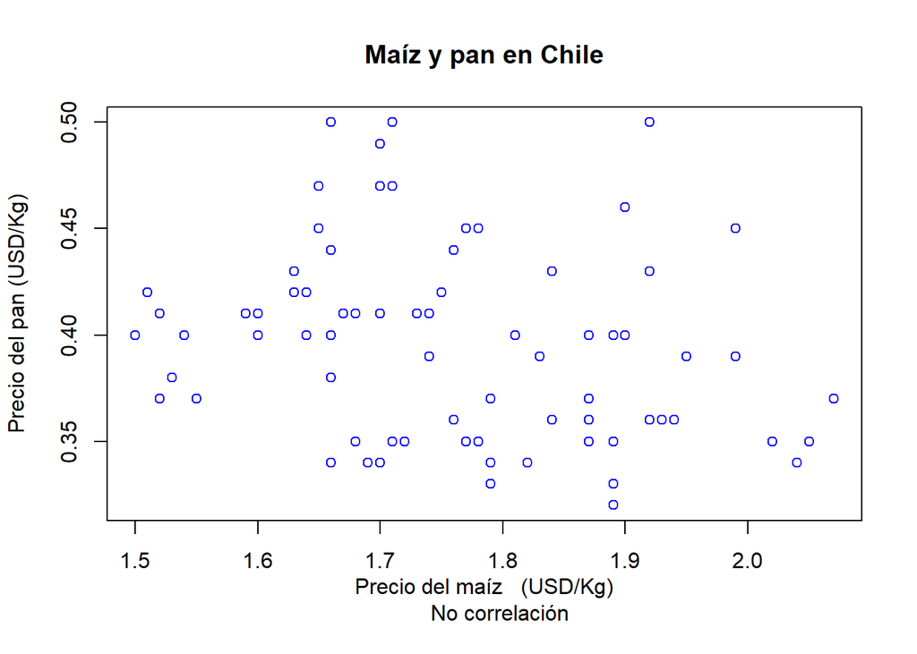

```r
plot( DFCH$`Maiz MIN USD/Kg`~ DFCH$`Pan MIN USD/KG` ,col="blue",main=("Maíz y pan en Chile"), xlab="Precio del maíz   (USD/Kg)
     No correlación", ylab = "Precio del pan (USD/Kg)")
```

► Correlación mínima negativa

```r
cor(DFCH$`Maiz MIN USD/Kg`, DFCH$`Pan MIN USD/KG`)
```

```
## [1] -0.2477756
```

► Coeficiente de determinación porcentual

```r
((cor(DFCH$`Maiz MIN USD/Kg`, DFCH$`Pan MIN USD/KG`) )^2)*100
```

```
## [1] 6.139276
```

### ▲▼▲▼▲▼▲▼▲▼▲▼▲▼▲ Predicciones ▼▲▼▲▼▲▼▲▼▲▼▲▼▲▼

Utilizando la ecuación de la recta de regresión, calculado anteriormente, podemos predecir los siguientes escenarios:

► Predicción 1: El precio del pan en Brasil, si el trigo tiene un precio de 1 USD/Kg

Ecuación de la línea de regresión

```r
X = 1
Y = -0.6725814 +  4.371288 * X
Y
```

```
## [1] 3.698707
```

Resultado : EL precio del pan en Brasil estaría en 3.698707 USD/Kg

► Predicción 2: El precio del trigo minorista en Brasil, si el trigo mayorista tiene un precio de 3 USD/Kg

Ecuación de la línea de regresión

```r
X = 3
Y = 0.008792  + 1.559784 * X
Y
```

```
## [1] 4.688144
```

Resultado: EL precio del trigo minorista, estaría en 4.688144 USD/Kg

► Predicción 3: El precio de la papa minorista en Ecuador, si la papa mayorista tiene un precio de 1.5 USD/Kg

► Ecuación de la línea de regresión

```r
X = 1.5
Y = 0.1821747 + 0.7903184 * X
Y
```

```
## [1] 1.367652
```

Resultado: EL precio de la papa minorista tendría un valor de 1.367652 USD/Kg

### ▲▼▲▼▲▼▲▼▲▼▲▼▲▼▲ Conclusiones ▼▲▼▲▼▲▼▲▼▲▼▲▼▲▼

### **Identificar la evolución de productos de la canasta básica familiar durante los últimos 5 años**

De los histogramas analizado pudimos determinar que:

pan: Brasil ha mantenido el costo más alto y bolivia el más bajo con respecto a los otros países papa: Chile ha mantenido el costo más alto y ecuador el más bajo con respecto a los otros países arroz: Chile ha mantenido el costo más alto y brasil el más bajo con respecto a los otros países maiz: Perú ha mantenido el costo más alto y brasil el más bajo con respecto a los otros países trigo: Perú ha mantenido el costo más alto y chile el más bajo con respecto a los otros países

### **Contrastar la información en 6 países de Latinoamérica**

Usamos el patrón producto - Latinoamérica para contrastar como a afectado cada producto un determinado producto en cada uno de los países

El área de verde representa al producto más caro, la de rojo el mas barato , Atípico representa que su boxplot presentó mayor cantidad de valores atípicos, el + representa la mayor dispersión en su precio y el - representa la menor dispersión

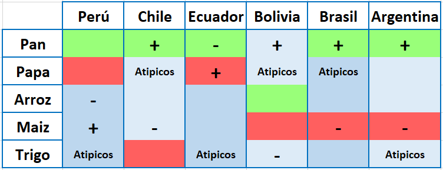

De la tabla descubrimos que el producto de la canasta básica más caro es el pan, salvo en Bolivia, pensamos que esto se debe a subsidios del gobierno boliviano que a hecho que su precio en dólares se mantenga casi constante.

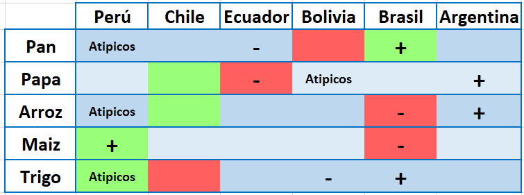

De la tabla descubrimos que el pan presenta mayor relevancia en brasil, la papa presenta poca relevancia en ecuador, el arroz presenta poca relevancia en brasil, el maíz y el trigo presenta mayor relevancia en Perú . Además que el maíz es el que presenta menos valores atípicos de todos los productos.

### **Determinar los años de mayor y menor costo de cada producto en la última década**

Empleamos el patrón producto - año para poder averiguarlo

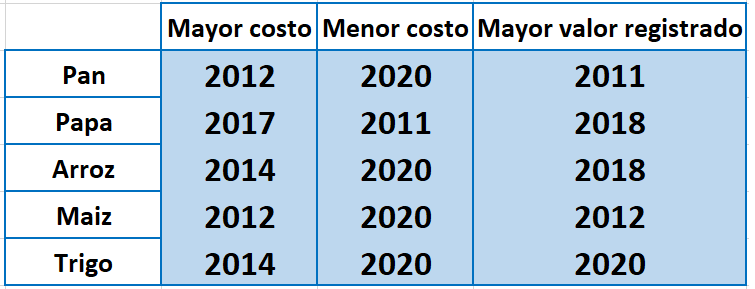

Hipótesis

### **Existe correlación entre el precio del pan y el trigo**

Si pero solo para los países de Perú y brasil donde presentan una correlación fuerte positiva. Esto se debe porque el pan de estos países depende fuertemente del trigo. Ademas que en el caso de Bolivia esta se ve afectada por los subsidios hacia el pan.

### **Conclusiones adicionales**

#2 ► Entre el año 2000 hasta la actualidad, por lo general, los alimentos de estudio no superaron la media en su precio final tanto para la venta por menor cómo por mayor. Lo que nos indica que el actual incremento que se percibe es producto de diversos factores externos que priman en contra la economía. Como la inflación, crisis económicas, entre otros.